# Diabetes

## Project 1

### Visualisasi Data - Dibetes

### Kasus 1: Pima Indian Diabetes Data Set (Soal 1 - 2)

Tampilkan visualisasi distribusi data untuk variabel "Glucose" dan "Insulin", lalu jelaskan hasil distribusinya.

#### Code

```python
# type your code here
import pandas as pd
import matplotlib as mpl
import seaborn as sns
import matplotlib.pyplot as plt; plt.style.use('fivethirtyeight')
mpl.style.use('ggplot')

!git clone https://github.com/andrewsihotang/tubesvisdat1.git
```

```
fatal: destination path 'tubesvisdat1' already exists and is not an empty directory.
```

```python
data1 = pd.read_csv('/content/tubesvisdat1/file/diabetes.csv')
data1
```

|  | Pregnancies | Glucose | BloodPressure | SkinThickness | Insulin | BMI | DiabetesPedigreeFunction | Age | Outcome |
| --- | --- | --- | --- | --- | --- | --- | --- | --- | --- |
| 0 | 6 | 148 | 72 | 35 | 0 | 33.6 | 0.627 | 50 | 1 |
| 1 | 1 | 85 | 66 | 29 | 0 | 26.6 | 0.351 | 31 | 0 |
| 2 | 8 | 183 | 64 | 0 | 0 | 23.3 | 0.672 | 32 | 1 |
| 3 | 1 | 89 | 66 | 23 | 94 | 28.1 | 0.167 | 21 | 0 |
| 4 | 0 | 137 | 40 | 35 | 168 | 43.1 | 2.288 | 33 | 1 |
| ... | ... | ... | ... | ... | ... | ... | ... | ... | ... |
| 763 | 10 | 101 | 76 | 48 | 180 | 32.9 | 0.171 | 63 | 0 |
| 764 | 2 | 122 | 70 | 27 | 0 | 36.8 | 0.340 | 27 | 0 |
| 765 | 5 | 121 | 72 | 23 | 112 | 26.2 | 0.245 | 30 | 0 |
| 766 | 1 | 126 | 60 | 0 | 0 | 30.1 | 0.349 | 47 | 1 |
| 767 | 1 | 93 | 70 | 31 | 0 | 30.4 | 0.315 | 23 | 0 |

768 rows × 9 columns

```python
#split data
clt = data1[['Glucose','Insulin']]
print(clt)
```

```
     Glucose  Insulin
0        148        0
1         85        0
2        183        0
3         89       94
4        137      168
..       ...      ...
763      101      180
764      122        0
765      121      112
766      126        0
767       93        0

[768 rows x 2 columns]
```

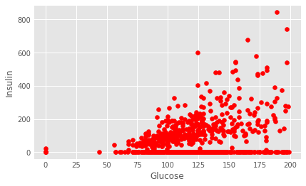

```python
plt.scatter(clt['Glucose'], clt['Insulin'], color = 'red')
plt.xlabel('Glucose')
plt.ylabel('Insulin')
plt.show()
```

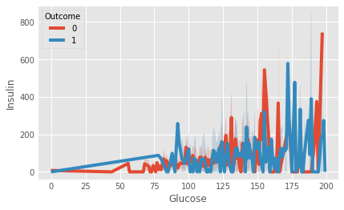

```python
sns.lineplot(x='Glucose',y='Insulin',hue='Outcome',data=data1)
```

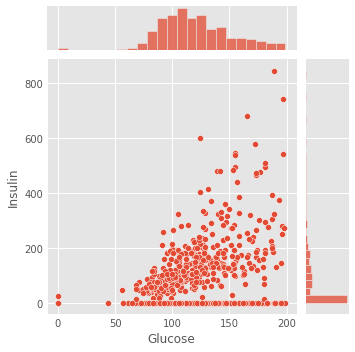

```python
sns.jointplot(x="Glucose", y="Insulin", data=data1, size=5)
```

#### Penjelasan

Dilihat dari hasil visualisasi, dapat dilihat persebaran data antara atribut 'Glucose' dan 'Insulin' dimana nilai dari atribut 'Glucose' lebih mudah untuk di teliti karena nilainya yang bervariasi, sedangkan untuk 'Insulin' sebagian besar datanya berkumpul pada nilai 0 sehingga sedikit lebih sulit untuk di teliti.

### Soal 2 (25 poin)

Tampilkan visualisasi dari korelasi (i) antar variabel dan (ii) antara variabel dan target, lalu jelaskan hasil korelasinya.

#### Code

Kolerasi antara variable

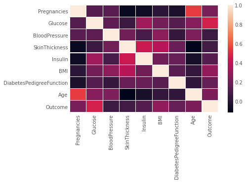

```python
# type your code here
sns.heatmap(data1.corr(), linewidths=.01, vmax=1)
```

Korelasi antara variable dan target

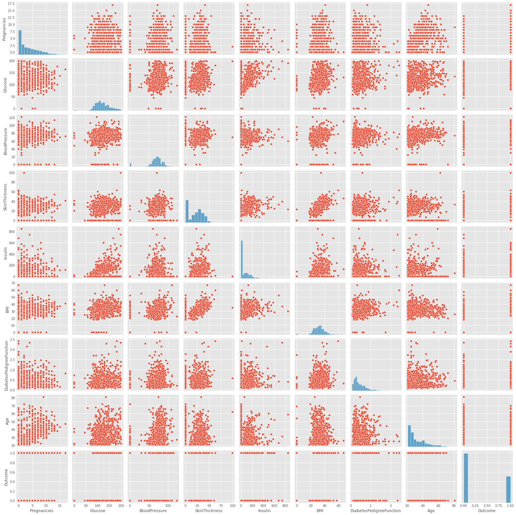

```python
sns.pairplot(data1)
```

#### Penjelasan

Korelasi antar variable, agar dapat meliaht variasi nilai antar variable maka digunakan visualisasi heatmap. Kemudian untuk korelasi variable dengan target, perpaduan histogram dan scatterplot dapat memperlihatkan visualisasi persebaran data dengan target yang ingin dituju. Untuk korelasi antara variable dan target menggunakan pairplot.

### Kasus 2: Stock Market Analysis (Soal 3 - 4)

Pada kasus ini, kita akan membandingkan beberapa parameter yang diturunkan dari data historis harga saham dari 3 perusahaan, yaitu Nasdaq, Nikkei dan Hang Seng. Data set dapat diunduh melalui [tautan ini](https://www.dl.dropboxusercontent.com/s/0wny6x5sio9nvap/stock_market.zip?dl=0).

Lakukanlah *trend analysis* nilai *daily percentage change* dari ketiga harga saham tersebut selama tahun 2019, lalu tampilkan dan jelaskan melalui visualisasi data. *Trend analysis* dilakukan dengan menggunakan hubungan berikut:

[figure not shown]

#### Code

```python
# type your code here
import pandas as pd
import numpy as np
```

NASDAQ

```python
dataNasdaq = pd.read_csv('/content/tubesvisdat1/file/Nasdaq.csv', parse_dates=True)
dataNasdaq['Date'] = pd.to_datetime(dataNasdaq['Date'])
dataNasdaq['year']= dataNasdaq['Date'].dt.year
dataNasdaq_target = dataNasdaq[dataNasdaq['year']== 2019]

dataNasdaq_target['Change'] = dataNasdaq_target.Close.pct_change() * 100

dataNasdaq_target
```

|  | Date | Open | High | Low | Close | Adj Close | Volume | year | Change |
| --- | --- | --- | --- | --- | --- | --- | --- | --- | --- |
| 49 | 2019-01-02 | 6506.910156 | 6693.709961 | 6506.879883 | 6665.939941 | 6665.939941 | 2261800000 | 2019 | NaN |
| 50 | 2019-01-03 | 6584.770020 | 6600.209961 | 6457.129883 | 6463.500000 | 6463.500000 | 2607290000 | 2019 | -3.036930 |
| 51 | 2019-01-04 | 6567.140137 | 6760.689941 | 6554.240234 | 6738.859863 | 6738.859863 | 2579550000 | 2019 | 4.260228 |
| 52 | 2019-01-07 | 6757.529785 | 6855.600098 | 6741.399902 | 6823.470215 | 6823.470215 | 2507550000 | 2019 | 1.255559 |
| 53 | 2019-01-08 | 6893.439941 | 6909.580078 | 6795.859863 | 6897.000000 | 6897.000000 | 2380290000 | 2019 | 1.077601 |
| ... | ... | ... | ... | ... | ... | ... | ... | ... | ... |
| 296 | 2019-12-24 | 8955.009766 | 8957.120117 | 8934.360352 | 8952.879883 | 8952.879883 | 1014520000 | 2019 | 0.080816 |
| 297 | 2019-12-26 | 8970.209961 | 9022.459961 | 8968.459961 | 9022.389648 | 9022.389648 | 1634920000 | 2019 | 0.776396 |
| 298 | 2019-12-27 | 9049.469727 | 9052.000000 | 8987.320313 | 9006.620117 | 9006.620117 | 1832200000 | 2019 | -0.174782 |
| 299 | 2019-12-30 | 9004.450195 | 9006.360352 | 8909.190430 | 8945.990234 | 8945.990234 | 2042420000 | 2019 | -0.673170 |
| 300 | 2019-12-31 | 8918.740234 | 8975.360352 | 8912.769531 | 8972.599609 | 8972.599609 | 2182800000 | 2019 | 0.297445 |

252 rows × 9 columns

```python
dataNasdaq_target['Trend'] = np.nan

dataNasdaq_target['Trend'] = np.where(dataNasdaq_target['Change'] <= -7, 'Bear Drop', dataNasdaq_target['Trend'])
dataNasdaq_target['Trend'] = np.where((dataNasdaq_target['Change'] > -7) & (dataNasdaq_target['Change'] <= -3), 'Among Top Losers', dataNasdaq_target['Trend'])
dataNasdaq_target['Trend'] = np.where((dataNasdaq_target['Change'] > -3) & (dataNasdaq_target['Change'] <= -1), 'Negative', dataNasdaq_target['Trend'])
dataNasdaq_target['Trend'] = np.where((dataNasdaq_target['Change'] > -1) & (dataNasdaq_target['Change'] <= -0.5), 'Slight Negative', dataNasdaq_target['Trend'])
dataNasdaq_target['Trend'] = np.where((dataNasdaq_target['Change'] > -0.5) & (dataNasdaq_target['Change'] <= 0.5), 'Slight or No Change', dataNasdaq_target['Trend'])
dataNasdaq_target['Trend'] = np.where((dataNasdaq_target['Change'] > 0.5) & (dataNasdaq_target['Change'] <= 1), 'Slight Positive', dataNasdaq_target['Trend'])
dataNasdaq_target['Trend'] = np.where((dataNasdaq_target['Change'] > 1) & (dataNasdaq_target['Change'] <= 3), 'Positive', dataNasdaq_target['Trend'])
dataNasdaq_target['Trend'] = np.where((dataNasdaq_target['Change'] > 3) & (dataNasdaq_target['Change'] <= 7), 'Among Top Gathers', dataNasdaq_target['Trend'])
dataNasdaq_target['Trend'] = np.where(dataNasdaq_target['Change'] > 7, 'Bull Run', dataNasdaq_target['Trend'])

dataNasdaq_target
```

[output not shown]

|  | Date | Open | High | Low | Close | Adj Close | Volume | year | Change | Trend |
| --- | --- | --- | --- | --- | --- | --- | --- | --- | --- | --- |
| 49 | 2019-01-02 | 6506.910156 | 6693.709961 | 6506.879883 | 6665.939941 | 6665.939941 | 2261800000 | 2019 | NaN | nan |
| 50 | 2019-01-03 | 6584.770020 | 6600.209961 | 6457.129883 | 6463.500000 | 6463.500000 | 2607290000 | 2019 | -3.036930 | Among Top Losers |
| 51 | 2019-01-04 | 6567.140137 | 6760.689941 | 6554.240234 | 6738.859863 | 6738.859863 | 2579550000 | 2019 | 4.260228 | Among Top Gathers |
| 52 | 2019-01-07 | 6757.529785 | 6855.600098 | 6741.399902 | 6823.470215 | 6823.470215 | 2507550000 | 2019 | 1.255559 | Positive |
| 53 | 2019-01-08 | 6893.439941 | 6909.580078 | 6795.859863 | 6897.000000 | 6897.000000 | 2380290000 | 2019 | 1.077601 | Positive |
| ... | ... | ... | ... | ... | ... | ... | ... | ... | ... | ... |
| 296 | 2019-12-24 | 8955.009766 | 8957.120117 | 8934.360352 | 8952.879883 | 8952.879883 | 1014520000 | 2019 | 0.080816 | Slight or No Change |
| 297 | 2019-12-26 | 8970.209961 | 9022.459961 | 8968.459961 | 9022.389648 | 9022.389648 | 1634920000 | 2019 | 0.776396 | Slight Positive |
| 298 | 2019-12-27 | 9049.469727 | 9052.000000 | 8987.320313 | 9006.620117 | 9006.620117 | 1832200000 | 2019 | -0.174782 | Slight or No Change |
| 299 | 2019-12-30 | 9004.450195 | 9006.360352 | 8909.190430 | 8945.990234 | 8945.990234 | 2042420000 | 2019 | -0.673170 | Slight Negative |
| 300 | 2019-12-31 | 8918.740234 | 8975.360352 | 8912.769531 | 8972.599609 | 8972.599609 | 2182800000 | 2019 | 0.297445 | Slight or No Change |

252 rows × 10 columns

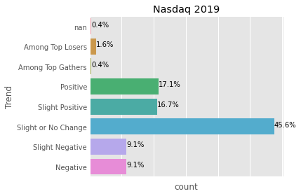

```python
p_dataNasdaq = sns.countplot(y="Trend", data=dataNasdaq_target)

p_dataNasdaq.set_xticklabels(p_dataNasdaq.get_xticklabels(), rotation=40, ha="right")
total = len(dataNasdaq_target['Trend'])
for p in p_dataNasdaq.patches:
        percentage = '{:.1f}%'.format(100 * p.get_width()/total)
        x = p.get_x() + p.get_width() + 0.02
        y = p.get_y() + p.get_height()/2
        p_dataNasdaq.annotate(percentage, (x, y))
plt.title('Nasdaq 2019')
plt.tight_layout()
plt.show()
```

NIKKEI

```python
dataNikkei = pd.read_csv('/content/tubesvisdat1/file/Nikkei.csv', parse_dates=True)
dataNikkei['Date'] = pd.to_datetime(dataNikkei['Date'])
dataNikkei['year'] = dataNikkei['Date'].dt.year
dataNikkei_target = dataNikkei[dataNikkei['year']== 2019]
dataNikkei_target['Change'] = dataNikkei_target.Close.pct_change() * 100
dataNikkei_target
```

|  | Date | Open | High | Low | Close | Adj Close | Volume | year | Change |
| --- | --- | --- | --- | --- | --- | --- | --- | --- | --- |
| 52 | 2019-01-04 | 19655.130859 | 19692.580078 | 19241.369141 | 19561.960938 | 19561.960938 | 91600.0 | 2019 | NaN |
| 53 | 2019-01-07 | 19944.609375 | 20266.220703 | 19920.800781 | 20038.970703 | 20038.970703 | 81500.0 | 2019 | 2.438456 |
| 54 | 2019-01-08 | 20224.669922 | 20347.919922 | 20106.359375 | 20204.039063 | 20204.039063 | 86400.0 | 2019 | 0.823737 |
| 55 | 2019-01-09 | 20366.300781 | 20494.349609 | 20331.199219 | 20427.060547 | 20427.060547 | 72800.0 | 2019 | 1.103846 |
| 56 | 2019-01-10 | 20270.880859 | 20345.919922 | 20101.929688 | 20163.800781 | 20163.800781 | 73700.0 | 2019 | -1.288779 |
| ... | ... | ... | ... | ... | ... | ... | ... | ... | ... |
| 288 | 2019-12-24 | 23839.179688 | 23853.560547 | 23796.349609 | 23830.580078 | 23830.580078 | 37900.0 | 2019 | 0.039758 |
| 289 | 2019-12-25 | 23813.589844 | 23824.849609 | 23782.869141 | 23782.869141 | 23782.869141 | 31600.0 | 2019 | -0.200209 |
| 290 | 2019-12-26 | 23787.699219 | 23931.509766 | 23775.400391 | 23924.919922 | 23924.919922 | 40300.0 | 2019 | 0.597282 |
| 291 | 2019-12-27 | 23953.750000 | 23967.179688 | 23837.720703 | 23837.720703 | 23837.720703 | 44800.0 | 2019 | -0.364470 |
| 292 | 2019-12-30 | 23770.929688 | 23782.490234 | 23656.619141 | 23656.619141 | 23656.619141 | 41600.0 | 2019 | -0.759727 |

241 rows × 9 columns

```python
dataNikkei_target['Trend'] = np.nan

dataNikkei_target['Trend'] = np.where(dataNikkei_target['Change'] <= -7, 'Bear Drop', dataNikkei_target['Trend'])
dataNikkei_target['Trend'] = np.where((dataNikkei_target['Change'] > -7) & (dataNikkei_target['Change'] <= -3), 'Among Top Losers', dataNikkei_target['Trend'])
dataNikkei_target['Trend'] = np.where((dataNikkei_target['Change'] > -3) & (dataNikkei_target['Change'] <= -1), 'Negative', dataNikkei_target['Trend'])
dataNikkei_target['Trend'] = np.where((dataNikkei_target['Change'] > -1) & (dataNikkei_target['Change'] <= -0.5), 'Slight Negative', dataNikkei_target['Trend'])
dataNikkei_target['Trend'] = np.where((dataNikkei_target['Change'] > -0.5) & (dataNikkei_target['Change'] <= 0.5), 'Slight or No Change', dataNikkei_target['Trend'])
dataNikkei_target['Trend'] = np.where((dataNikkei_target['Change'] > 0.5) & (dataNikkei_target['Change'] <= 1), 'Slight Positive', dataNikkei_target['Trend'])
dataNikkei_target['Trend'] = np.where((dataNikkei_target['Change'] > 1) & (dataNikkei_target['Change'] <= 3), 'Positive', dataNikkei_target['Trend'])
dataNikkei_target['Trend'] = np.where((dataNikkei_target['Change'] > 3) & (dataNikkei_target['Change'] <= 7), 'Among Top Gathers', dataNikkei_target['Trend'])
dataNikkei_target['Trend'] = np.where(dataNikkei_target['Change'] > 7, 'Bull Run', dataNikkei_target['Trend'])

dataNikkei_target
```

[output not shown]

|  | Date | Open | High | Low | Close | Adj Close | Volume | year | Change | Trend |
| --- | --- | --- | --- | --- | --- | --- | --- | --- | --- | --- |
| 52 | 2019-01-04 | 19655.130859 | 19692.580078 | 19241.369141 | 19561.960938 | 19561.960938 | 91600.0 | 2019 | NaN | nan |
| 53 | 2019-01-07 | 19944.609375 | 20266.220703 | 19920.800781 | 20038.970703 | 20038.970703 | 81500.0 | 2019 | 2.438456 | Positive |
| 54 | 2019-01-08 | 20224.669922 | 20347.919922 | 20106.359375 | 20204.039063 | 20204.039063 | 86400.0 | 2019 | 0.823737 | Slight Positive |
| 55 | 2019-01-09 | 20366.300781 | 20494.349609 | 20331.199219 | 20427.060547 | 20427.060547 | 72800.0 | 2019 | 1.103846 | Positive |
| 56 | 2019-01-10 | 20270.880859 | 20345.919922 | 20101.929688 | 20163.800781 | 20163.800781 | 73700.0 | 2019 | -1.288779 | Negative |
| ... | ... | ... | ... | ... | ... | ... | ... | ... | ... | ... |
| 288 | 2019-12-24 | 23839.179688 | 23853.560547 | 23796.349609 | 23830.580078 | 23830.580078 | 37900.0 | 2019 | 0.039758 | Slight or No Change |
| 289 | 2019-12-25 | 23813.589844 | 23824.849609 | 23782.869141 | 23782.869141 | 23782.869141 | 31600.0 | 2019 | -0.200209 | Slight or No Change |
| 290 | 2019-12-26 | 23787.699219 | 23931.509766 | 23775.400391 | 23924.919922 | 23924.919922 | 40300.0 | 2019 | 0.597282 | Slight Positive |
| 291 | 2019-12-27 | 23953.750000 | 23967.179688 | 23837.720703 | 23837.720703 | 23837.720703 | 44800.0 | 2019 | -0.364470 | Slight or No Change |
| 292 | 2019-12-30 | 23770.929688 | 23782.490234 | 23656.619141 | 23656.619141 | 23656.619141 | 41600.0 | 2019 | -0.759727 | Slight Negative |

241 rows × 10 columns

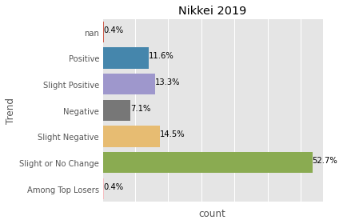

```python
p_dataNikkei = sns.countplot(y="Trend", data=dataNikkei_target)

p_dataNikkei.set_xticklabels(p_dataNikkei.get_xticklabels(), rotation=40, ha="right")
total = len(dataNikkei_target['Trend'])
for p in p_dataNikkei.patches:
        percentage = '{:.1f}%'.format(100 * p.get_width()/total)
        x = p.get_x() + p.get_width() + 0.02
        y = p.get_y() + p.get_height()/2
        p_dataNikkei.annotate(percentage, (x, y))
plt.title('Nikkei 2019')
plt.tight_layout()
plt.show()
```

Hang Seng

```python
dataHangSeng = pd.read_csv('/content/tubesvisdat1/file/Hang_Seng.csv')
dataHangSeng['Date'] = pd.to_datetime(dataHangSeng['Date'])
dataHangSeng['year']= dataHangSeng['Date'].dt.year
dataHangSeng_target = dataHangSeng[dataHangSeng['year']== 2019]
dataHangSeng_target['Change'] = dataHangSeng_target.Close.pct_change() * 100
dataHangSeng_target
```

|  | Date | Open | High | Low | Close | Adj Close | Volume | year | Change |
| --- | --- | --- | --- | --- | --- | --- | --- | --- | --- |
| 50 | 2019-01-02 | 25824.439453 | 25824.439453 | 25055.269531 | 25130.349609 | 25130.349609 | 1.666316e+09 | 2019 | NaN |
| 51 | 2019-01-03 | 25077.679688 | 25262.210938 | 24896.869141 | 25064.359375 | 25064.359375 | 1.481292e+09 | 2019 | -0.262592 |
| 52 | 2019-01-04 | 24946.119141 | 25626.029297 | 24924.730469 | 25626.029297 | 25626.029297 | 1.708572e+09 | 2019 | 2.240911 |
| 53 | 2019-01-07 | 26015.839844 | 26043.640625 | 25753.460938 | 25835.699219 | 25835.699219 | 1.447090e+09 | 2019 | 0.818191 |
| 54 | 2019-01-08 | 25852.500000 | 25960.890625 | 25688.500000 | 25875.449219 | 25875.449219 | 1.578206e+09 | 2019 | 0.153857 |
| ... | ... | ... | ... | ... | ... | ... | ... | ... | ... |
| 291 | 2019-12-23 | 28024.619141 | 28024.619141 | 27830.080078 | 27906.410156 | 27906.410156 | 1.216834e+09 | 2019 | 0.125794 |
| 292 | 2019-12-24 | 27901.509766 | 27921.289063 | 27792.660156 | 27864.210938 | 27864.210938 | 4.839841e+08 | 2019 | -0.151217 |
| 293 | 2019-12-27 | 28033.660156 | 28226.109375 | 28000.619141 | 28225.419922 | 28225.419922 | 1.375016e+09 | 2019 | 1.296319 |
| 294 | 2019-12-30 | 28250.480469 | 28418.650391 | 28165.130859 | 28319.390625 | 28319.390625 | 1.420447e+09 | 2019 | 0.332929 |
| 295 | 2019-12-31 | 28241.429688 | 28298.460938 | 28123.859375 | 28189.750000 | 28189.750000 | 8.737139e+08 | 2019 | -0.457780 |

246 rows × 9 columns

```python
dataHangSeng_target['Trend'] = np.nan

dataHangSeng_target['Trend'] = np.where(dataHangSeng_target['Change'] <= -7, 'Bear Drop', dataHangSeng_target['Trend'])
dataHangSeng_target['Trend'] = np.where((dataHangSeng_target['Change'] > -7) & (dataHangSeng_target['Change'] <= -3), 'Among Top Losers', dataHangSeng_target['Trend'])
dataHangSeng_target['Trend'] = np.where((dataHangSeng_target['Change'] > -3) & (dataHangSeng_target['Change'] <= -1), 'Negative', dataHangSeng_target['Trend'])
dataHangSeng_target['Trend'] = np.where((dataHangSeng_target['Change'] > -1) & (dataHangSeng_target['Change'] <= -0.5), 'Slight Negative', dataHangSeng_target['Trend'])
dataHangSeng_target['Trend'] = np.where((dataHangSeng_target['Change'] > -0.5) & (dataHangSeng_target['Change'] <= 0.5), 'Slight or No Change', dataHangSeng_target['Trend'])
dataHangSeng_target['Trend'] = np.where((dataHangSeng_target['Change'] > 0.5) & (dataHangSeng_target['Change'] <= 1), 'Slight Positive', dataHangSeng_target['Trend'])
dataHangSeng_target['Trend'] = np.where((dataHangSeng_target['Change'] > 1) & (dataHangSeng_target['Change'] <= 3), 'Positive', dataHangSeng_target['Trend'])
dataHangSeng_target['Trend'] = np.where((dataHangSeng_target['Change'] > 3) & (dataHangSeng_target['Change'] <= 7), 'Among Top Gathers', dataHangSeng_target['Trend'])
dataHangSeng_target['Trend'] = np.where(dataHangSeng_target['Change'] > 7, 'Bull Run', dataHangSeng_target['Trend'])

dataHangSeng_target
```

[output not shown]

|  | Date | Open | High | Low | Close | Adj Close | Volume | year | Change | Trend |
| --- | --- | --- | --- | --- | --- | --- | --- | --- | --- | --- |
| 50 | 2019-01-02 | 25824.439453 | 25824.439453 | 25055.269531 | 25130.349609 | 25130.349609 | 1.666316e+09 | 2019 | NaN | nan |
| 51 | 2019-01-03 | 25077.679688 | 25262.210938 | 24896.869141 | 25064.359375 | 25064.359375 | 1.481292e+09 | 2019 | -0.262592 | Slight or No Change |
| 52 | 2019-01-04 | 24946.119141 | 25626.029297 | 24924.730469 | 25626.029297 | 25626.029297 | 1.708572e+09 | 2019 | 2.240911 | Positive |
| 53 | 2019-01-07 | 26015.839844 | 26043.640625 | 25753.460938 | 25835.699219 | 25835.699219 | 1.447090e+09 | 2019 | 0.818191 | Slight Positive |
| 54 | 2019-01-08 | 25852.500000 | 25960.890625 | 25688.500000 | 25875.449219 | 25875.449219 | 1.578206e+09 | 2019 | 0.153857 | Slight or No Change |
| ... | ... | ... | ... | ... | ... | ... | ... | ... | ... | ... |
| 291 | 2019-12-23 | 28024.619141 | 28024.619141 | 27830.080078 | 27906.410156 | 27906.410156 | 1.216834e+09 | 2019 | 0.125794 | Slight or No Change |
| 292 | 2019-12-24 | 27901.509766 | 27921.289063 | 27792.660156 | 27864.210938 | 27864.210938 | 4.839841e+08 | 2019 | -0.151217 | Slight or No Change |
| 293 | 2019-12-27 | 28033.660156 | 28226.109375 | 28000.619141 | 28225.419922 | 28225.419922 | 1.375016e+09 | 2019 | 1.296319 | Positive |
| 294 | 2019-12-30 | 28250.480469 | 28418.650391 | 28165.130859 | 28319.390625 | 28319.390625 | 1.420447e+09 | 2019 | 0.332929 | Slight or No Change |
| 295 | 2019-12-31 | 28241.429688 | 28298.460938 | 28123.859375 | 28189.750000 | 28189.750000 | 8.737139e+08 | 2019 | -0.457780 | Slight or No Change |

246 rows × 10 columns

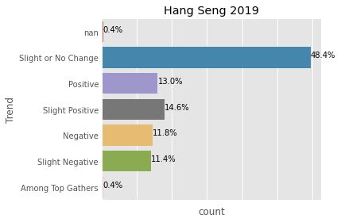

```python
p_dataHangSeng = sns.countplot(y="Trend", data=dataHangSeng_target)

p_dataHangSeng.set_xticklabels(p_dataHangSeng.get_xticklabels(), rotation=40, ha="right")
total = len(dataHangSeng_target['Trend'])
for p in p_dataHangSeng.patches:
        percentage = '{:.1f}%'.format(100 * p.get_width()/total)
        x = p.get_x() + p.get_width() + 0.02
        y = p.get_y() + p.get_height()/2
        p_dataHangSeng.annotate(percentage, (x, y))
plt.title('Hang Seng 2019')
plt.tight_layout()
plt.show()
```

#### Penjelasan

Saham Nasdaq : Dapat dilihat, pada tahun 2019 saham Nasdaq nilai among top gathers sebesar 0,4% (dikategorikan kecil) jika dibandingkan dengan nilai among top loser yaitu sebesar 1,6%.

Saham Hang_Seng: Dapat dilihat, pada tahun 2019 untuk nilai positive memiliki presentasi sebesar 13% yang lebih tinggi jika dibandingkan dengan nilai negative yang memiliki presentasi sebesar 11.8%, maka akan meringankan resiko. Dan juga nilai seperti slight or no change sebesar 48,4%, angka ini dapat meminimalisir kerugian dan ataupun berdampak sebaliknya, dan nilai slight positive sebesar 14,6%.

Lakukanlah analisis volatilitas dari ketiga harga saham tersebut selama tahun 2019, lalu tampilkan dan jelaskan hasil visualisasinya.

```python
c_dataNasdaq = dataNasdaq_target['Change']
c_dataNikkei = dataNikkei_target['Change']
c_dataHangSeng = dataHangSeng_target['Change']
```

```python
datatemp = dataHangSeng_target

datatemp['NIKKEI'] = c_dataNasdaq
datatemp['NASDAQ'] = c_dataNikkei
datatemp['HANGSENG'] = c_dataHangSeng

data_change = datatemp[['Date','NIKKEI','NASDAQ','HANGSENG']]

data_change.dropna(axis = 0, inplace = True)

data_change
```

|  | Date | NIKKEI | NASDAQ | HANGSENG |
| --- | --- | --- | --- | --- |
| 53 | 2019-01-07 | 1.077601 | 2.438456 | 0.818191 |
| 54 | 2019-01-08 | 0.871105 | 0.823737 | 0.153857 |
| 55 | 2019-01-09 | 0.416694 | 1.103846 | 2.268061 |
| 56 | 2019-01-10 | -0.208842 | -1.288779 | 0.223372 |
| 57 | 2019-01-11 | -0.940404 | 0.971535 | 0.549894 |
| ... | ... | ... | ... | ... |
| 288 | 2019-12-18 | 0.731109 | 0.039758 | 0.145455 |
| 289 | 2019-12-19 | 0.201433 | -0.200209 | -0.300244 |
| 290 | 2019-12-20 | 0.908434 | 0.597282 | 0.254885 |
| 291 | 2019-12-23 | 0.103581 | -0.364470 | 0.125794 |
| 292 | 2019-12-24 | 0.049640 | -0.759727 | -0.151217 |

240 rows × 4 columns

[figure not shown]

```python
#Memvisualiasikan volatility
vol = data_change[['NIKKEI', 'NASDAQ', 'HANGSENG']].rolling(7).std()*np.sqrt(7)
vol.plot(figsize = (15, 7))
plt.xlabel('Nikkei, Nasdaq, HangSeng volatility 2019')
```